# TaskRabbit Data Exercise (Mingliang Zhou)

GitHub: https://github.com/MingliangZhou/DS_Project_TR

```python
import numpy as np
import pandas as pd

import matplotlib
import matplotlib.pyplot as plt
%matplotlib inline

from jupyterthemes import jtplot
jtplot.style(theme='grade3')

import warnings
warnings.filterwarnings('ignore')
```

## Question 1

How many recommendation sets are in this data sample?

```python
df = pd.read_csv('../input/sample.csv')
df.info()
```

```
<class 'pandas.core.frame.DataFrame'>
RangeIndex: 30000 entries, 0 to 29999
Data columns (total 8 columns):
recommendation_id      30000 non-null object
created_at             30000 non-null object
tasker_id              30000 non-null int64
position               30000 non-null int64
hourly_rate            30000 non-null int64
num_completed_tasks    30000 non-null int64
hired                  30000 non-null int64
category               30000 non-null object
dtypes: int64(5), object(3)
memory usage: 1.8+ MB
```

```python
df['recommendation_id'].nunique()
```

```
2100
```

2100 recommendation sets

## Question 2

Each recommendation set shows from 1 to 15 Taskers, what is:

- average number of Taskers shown
- median number of Taskers shown

```python
df.groupby('recommendation_id')['tasker_id'].nunique().agg(['mean', 'median'])
```

```
mean      14.285714
median    15.000000
Name: tasker_id, dtype: float64
```

Average is 14.29  
Median is 15

## Question 3

How many total unique Taskers are there in this data sample?

```python
df['tasker_id'].nunique()
```

```
830
```

830 unique Taskers

## Question 4

Which Tasker has been shown the most?  
Which Tasker has been shown the least?

```python
dfTaskerShown = df.groupby('tasker_id')['recommendation_id'].count().\
    reset_index(name='countTaskerShown').sort_values(by='countTaskerShown', ascending=False)
dfTaskerShown.head()
```

|  | tasker_id | countTaskerShown |
| --- | --- | --- |
| 780 | 1014508755 | 608 |
| 502 | 1012043028 | 438 |
| 795 | 1014675294 | 387 |
| 789 | 1014629676 | 311 |
| 183 | 1008887321 | 290 |

```python
dfTaskerShown[dfTaskerShown['countTaskerShown']==1]['tasker_id'].values
```

```
array([1007383273, 1007246122, 1007295623, 1007480912, 1007638825,
       1006690425, 1014593279, 1006853970, 1006899551, 1010681878,
       1007472083, 1014926743, 1014547884, 1008919567, 1014478773,
       1010042971, 1009547227, 1011968845, 1009603880, 1012678504,
       1009612428, 1012386513, 1009618500, 1012364558, 1009641175,
       1011972750, 1012348656, 1012289475, 1010779242, 1009702351,
       1009712638, 1009754999, 1011985968, 1012166729, 1009772528,
       1012151299, 1010021990, 1010009736, 1012071620, 1009871933,
       1012805440, 1011957940, 1009461190, 1011952623, 1014439502,
       1014310300, 1007923586, 1008033678, 1014086818, 1013934937,
       1013854788, 1013830691, 1011901532, 1008368716, 1008469117,
       1013731883, 1008474216, 1013656032, 1008604368, 1008828652,
       1013573988, 1013573125, 1008870833, 1009994950, 1013362004,
       1009112003, 1011949117, 1010640007])
```

Tasker 1014508755 has been shown the most  
More than 1 Tasker has been shown the least: [1007383273, 1007246122, 1007295623, 1007480912, 1007638825, 1006690425, 1014593279, 1006853970, 1006899551, 1010681878, 1007472083, 1014926743, 1014547884, 1008919567, 1014478773, 1010042971, 1009547227, 1011968845, 1009603880, 1012678504, 1009612428, 1012386513, 1009618500, 1012364558, 1009641175, 1011972750, 1012348656, 1012289475, 1010779242, 1009702351, 1009712638, 1009754999, 1011985968, 1012166729, 1009772528, 1012151299, 1010021990, 1010009736, 1012071620, 1009871933, 1012805440, 1011957940, 1009461190, 1011952623, 1014439502, 1014310300, 1007923586, 1008033678, 1014086818, 1013934937, 1013854788, 1013830691, 1011901532, 1008368716, 1008469117, 1013731883, 1008474216, 1013656032, 1008604368, 1008828652, 1013573988, 1013573125, 1008870833, 1009994950, 1013362004, 1009112003, 1011949117, 1010640007]

## Question 5

Which Tasker has been hired the most?  
Which Tasker has been hired the least?

```python
dfTaskerHired = df[df['hired']==1].groupby('tasker_id')['recommendation_id'].count().\
    reset_index(name='countTaskerHired').sort_values(by='countTaskerHired', ascending=False)
dfTaskerHired.head()
```

|  | tasker_id | countTaskerHired |
| --- | --- | --- |
| 195 | 1012043028 | 59 |
| 222 | 1013131759 | 39 |
| 236 | 1013359522 | 37 |
| 225 | 1013165984 | 36 |
| 261 | 1013794735 | 35 |

```python
dfTaskerHired[dfTaskerHired['countTaskerHired']==1]['tasker_id'].values
```

```
array([1008111352, 1007477780, 1006720321, 1015009096, 1014832736,
       1007164698, 1007146669, 1007898815, 1013852438, 1014740602,
       1013865107, 1007480912, 1008037901, 1014251534, 1014629676,
       1008008634, 1014100703, 1007702812, 1014478773, 1014157578,
       1013745898, 1007955495, 1014212647, 1008030151, 1008862713,
       1013745838, 1009966564, 1011920226, 1011914012, 1009299585,
       1010801075, 1010752503, 1009348455, 1009393887, 1010578972,
       1010565292, 1010438496, 1010008242, 1009606144, 1013711863,
       1009917428, 1009865854, 1009848016, 1009616142, 1009751605,
       1009733517, 1009729754, 1009703547, 1009638159, 1009693303,
       1009638573, 1011985968, 1009230070, 1009192067, 1012170634,
       1013696131, 1013677268, 1008162664, 1013553854, 1008473496,
       1013443125, 1013434046, 1008724560, 1013305557, 1008762938,
       1008782548, 1008790779, 1008887321, 1013034579, 1008890855,
       1012719266, 1012666042, 1008903001, 1008930827, 1012278216,
       1008962854, 1008966829, 1012229493, 1015020347])
```

Tasker 1012043028 has been hired the most  
More than 1 Tasker has been hired the least (excluded Taskers who never been hired): [1008111352, 1007477780, 1006720321, 1015009096, 1014832736, 1007164698, 1007146669, 1007898815, 1013852438, 1014740602, 1013865107, 1007480912, 1008037901, 1014251534, 1014629676, 1008008634, 1014100703, 1007702812, 1014478773, 1014157578, 1013745898, 1007955495, 1014212647, 1008030151, 1008862713, 1013745838, 1009966564, 1011920226, 1011914012, 1009299585, 1010801075, 1010752503, 1009348455, 1009393887, 1010578972, 1010565292, 1010438496, 1010008242, 1009606144, 1013711863, 1009917428, 1009865854, 1009848016, 1009616142, 1009751605, 1009733517, 1009729754, 1009703547, 1009638159, 1009693303, 1009638573, 1011985968, 1009230070, 1009192067, 1012170634, 1013696131, 1013677268, 1008162664, 1013553854, 1008473496, 1013443125, 1013434046, 1008724560, 1013305557, 1008762938, 1008782548, 1008790779, 1008887321, 1013034579, 1008890855, 1012719266, 1012666042, 1008903001, 1008930827, 1012278216, 1008962854, 1008966829, 1012229493, 1015020347]

## Question 6

If we define the "Tasker conversion rate" as the number of times a Tasker has been hired, out of the number of times the Tasker has been shown, how many Taskers have a conversion rate of 100%?

```python
dfTaskerConv = pd.merge(dfTaskerShown, dfTaskerHired, on='tasker_id', how='left').fillna(0)
dfTaskerConv['tasker_conversion_rate'] = dfTaskerConv['countTaskerHired'] /\
    dfTaskerConv['countTaskerShown']
dfTaskerConv[dfTaskerConv['tasker_conversion_rate']==1]
```

|  | tasker_id | countTaskerShown | countTaskerHired | tasker_conversion_rate |
| --- | --- | --- | --- | --- |
| 505 | 1008861741 | 9 | 9.0 | 1.0 |
| 734 | 1008094420 | 2 | 2.0 | 1.0 |
| 750 | 1012369686 | 2 | 2.0 | 1.0 |
| 765 | 1007480912 | 1 | 1.0 | 1.0 |
| 776 | 1014478773 | 1 | 1.0 | 1.0 |
| 794 | 1011985968 | 1 | 1.0 | 1.0 |

6 Taskers

## Question 7

Would it be possible for all Taskers to have a conversion rate of 100%? Please explain your reasoning.

Since each recommendation hires only one Tasker, 100% conversion rate for all Taskers can only happen if each recommendation has only one Tasker shown, and that Tasker is also hired.

## Question 8

For each category, what is the average position of the Tasker who is hired?

```python
df[df['hired']==1].groupby('category')['position'].mean()
```

```
category
Furniture Assembly    3.611888
Mounting              4.596085
Moving Help           4.145359
Name: position, dtype: float64
```

Furniture Assembly: 3.61  
Mounting: 4.60  
Moving Help: 4.15

## Question 9

For each category, what is the average hourly rate and average number of completed tasks for the Taskers who are hired?

```python
df[df['hired']==1].groupby('category')[['hourly_rate', 'num_completed_tasks']].mean()
```

| category | hourly_rate | num_completed_tasks |
| --- | --- | --- |
| Furniture Assembly | 38.701049 | 249.020979 |
| Mounting | 50.154804 | 284.096085 |
| Moving Help | 63.012259 | 273.882662 |

Average hourly rate  
Furniture Assembly: 38.70  
Mounting: 50.15  
Moving Help: 63.01  
Average number of completed tasks  
Furniture Assembly: 249.02  
Mounting: 284.10  
Moving Help: 273.88

## Question 10

Based on the previous, how would you approach the question of: How can we use market data to suggest hourly rates to Taskers that would maximize their opportunity to be hired? Please describe in detail, with code and formulas that support your model.

One of the confounding attributes that determine the opportunity to be hired is the service quality of a Tasker. This is why we observed some taskers are still hired even though their hourly rate is higher than their competitors.

Unfortunately, the attribute that reflects the service quality is not included in the data. num_completed_tasks is a poor estimate of service quality since it doesn't take running time into account, thus unfair to relatively new Taskers.

However, for each Tasker, service quality can be assumed to remains the same. We might get some insights here. The question is: do we have enough statistics and variation of hourly rates for each Tasker?

```python
df.groupby(['category', 'tasker_id'])['hourly_rate'].agg(['count', 'nunique']).\
    reset_index().sort_values(by=['count'], ascending=False).head(10)
```

|  | category | tasker_id | count | nunique |
| --- | --- | --- | --- | --- |
| 786 | Mounting | 1014508755 | 522 | 1 |
| 790 | Mounting | 1014629676 | 311 | 5 |
| 109 | Furniture Assembly | 1008887321 | 256 | 1 |
| 783 | Mounting | 1014423146 | 240 | 2 |
| 1171 | Moving Help | 1013283344 | 227 | 3 |
| 794 | Mounting | 1014675294 | 223 | 2 |
| 301 | Furniture Assembly | 1012043028 | 217 | 8 |
| 1242 | Moving Help | 1014157578 | 215 | 3 |
| 712 | Mounting | 1012721277 | 214 | 9 |
| 689 | Mounting | 1012043028 | 214 | 5 |

Unfortunately, there are neither enough statistics nor variation of hourly rates to extract useful information for each Tasker. This means we have to combine all Taskers together.

Even so, by assuming that the service qualities of the 'normal' Taskers (hourly rates within IQR) are roughly the same. We could might still spot some pattern.

Since each category have very different average/median hourly rates, the analysis is performed in each category. First, fill the histogram of hourly rates for each category, in three cases: hired, not hired and combined.

```python
categories = ['Furniture Assembly', 'Mounting', 'Moving Help']
hist_hourly_rate = [] # 3 categories | hired, not hired, combined
for category in categories:
    hired = np.histogram(df[(df['hired']==1) & (df['category']==category)]['hourly_rate']\
            .values, bins=np.linspace(0,200,41))
    unhired = np.histogram(df[(df['hired']==0) & (df['category']==category)]['hourly_rate']\
            .values, bins=np.linspace(0,200,41))
    combined = np.histogram(df[df['category']==category]['hourly_rate']\
            .values, bins=np.linspace(0,200,41))
    hist_hourly_rate.append([hired, unhired, combined])
```

Within each hourly rate range, the opportunity to be hired is defined as the number of hired Taskers out of the total number of shown taskers. They are shown in the following plots.

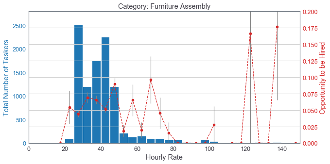

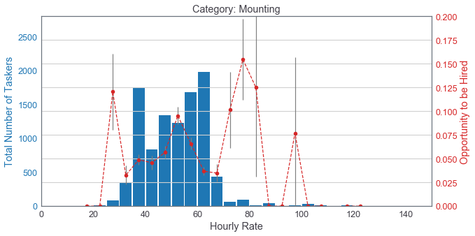

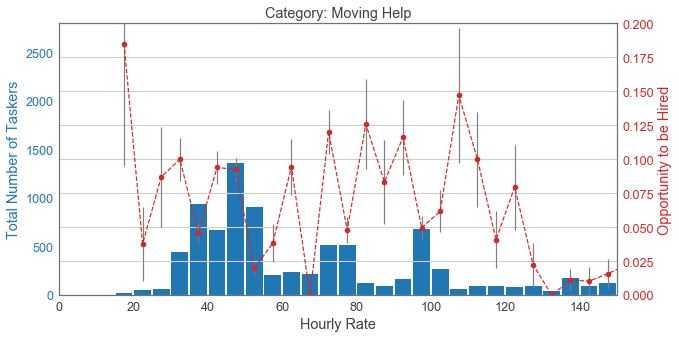

```python
xpos = np.linspace(2.5,197.5,40)
for iC in range(len(categories)):
    A, B = hist_hourly_rate[iC][0][0], hist_hourly_rate[iC][2][0]
    yerr = A/B*np.sqrt(1./A+1./B)
    fig = plt.figure(figsize=(10,5))
    ax1 = fig.add_subplot(1,1,1)
    ax1.grid(False)
    ax1.set_title('Category: {}'.format(categories[iC]))
    ax1.set_xlabel('Hourly Rate')
    ax1.set_ylabel('Total Number of Taskers', color='tab:blue')
    ax1.bar(xpos, hist_hourly_rate[iC][2][0], width=4.5, color='tab:blue')
    ax1.tick_params(axis='y', labelcolor='tab:blue')
    ax1.set_xlim([0,150])
    ax1.set_ylim([0,2800])
    ax2 = ax1.twinx()
    ax2.set_ylabel('Opportunity to be Hired', color='tab:red')
    ax2.errorbar(xpos, hist_hourly_rate[iC][0][0]/hist_hourly_rate[iC][2][0],
                 yerr=yerr, ecolor='gray', fmt='o--', color='tab:red')
    ax2.set_ylim([0,0.2])
    ax2.tick_params(axis='y', labelcolor='tab:red')
```

For furniture assembly, most Taskers have hourly rate between 25 to 50. The opportunity does not change dramatically as a function of hourly rate. Thus a higher rate is suggested in order to increase revenue: we suggest 45 to 50.

For mounting, most Taskers have hourly rate between 35 to 65. The opportunity is significantly higher for hourly rate between 50 to 55. Comparing hourly rate range 50-55 to 55-60, the expected revenue per order is increased by 0.0954 *52.5 - 0.0660* 57.5 = 1.213. This means that 50-55 hourly rate not only increases the opportunity to be hired, but also increases revenue overall. Thus we suggest 50-55.

For moving help, the situation is more complicated. There are multiple clusters of hourly rates: around 50, 70 and 100 respectively. This is expected since compared with furniture assembly and mounting, moving requires more expertises and the service quality will decide the opportunity to be hired. So more information is required and the suggestions will depend on different clusters of Taskers.